# dplyr

#### *Jerrin Joe Varghese*

##### Age : 26

#### **About Me** :

##### I am a data Science student at mercyhurst.Worked at Einfochips for 3 years as

##### a device driver engineer for Texas instruments.

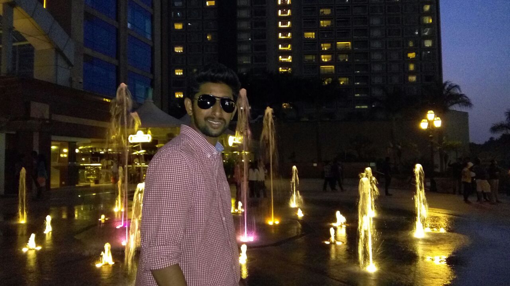

### Introduction

*dplyr is a new package which provides a set of tools to efficiently manipulate datasets in R. dplyr is the next iteration of plyr, focussing on only data frames. dplyr is faster and has a more consistent API and is easier to use.*

With the help of these shown libraries, we will analyze and understand some of

the features of dplyr.

**Note : Lahman is a baseball dataset. It contains information of baseball players.**

```r
library(Lahman)
library(dplyr)
```

** Lets go through some of the features with example**

#### Filtering Columns and Rows

*When using dplyr, you can filter columns and rows by using select and filter. Let’s look at an example using Lahman data base. We first have to load the Lahman and dplyr packages.*

*Now, Suppose we would like to see the homerun totals for the 1927 New York Yankees, We could run the following Code :*

```r
Batting%>%
  select(playerID,yearID,teamID,HR)%>%
  filter(teamID=='NYA' & yearID==1927)
```

```
##     playerID yearID teamID HR
## 1  beallwa01   1927    NYA  0
## 2  bengobe01   1927    NYA  0
## 3  collipa01   1927    NYA  7
## 4  combsea01   1927    NYA  6
## 5  duganjo01   1927    NYA  2
## 6  durstce01   1927    NYA  0
## 7  gazelmi01   1927    NYA  0
## 8  gehrilo01   1927    NYA 47
## 9  giardjo01   1927    NYA  0
## 10 grabojo01   1927    NYA  0
## 11  hoytwa01   1927    NYA  0
## 12 koenima01   1927    NYA  3
## 13 lazzeto01   1927    NYA 18
## 14 meusebo01   1927    NYA  8
## 15 moorewi01   1927    NYA  1
## 16 morehra01   1927    NYA  1
## 17 paschbe01   1927    NYA  2
## 18 pennohe01   1927    NYA  0
## 19 pipgrge01   1927    NYA  1
## 20 ruethdu01   1927    NYA  1
## 21  ruthba01   1927    NYA 60
## 22 shawkbo01   1927    NYA  0
## 23 shockur01   1927    NYA  0
## 24 thomamy01   1927    NYA  0
## 25  weraju01   1927    NYA  1
```

Please find some examples

Example 1. # more than 50 Home Runs and arrange Solution :

```r
        Batting%>%
          select(playerID,yearID,teamID,HR)%>%
          filter(HR>50)%>%
          arrange(HR) # assending order by default.
```

```
##     playerID yearID teamID HR
## 1  kinerra01   1947    PIT 51
## 2   mizejo01   1947    NY1 51
## 3   mayswi01   1955    NY1 51
## 4  fieldce01   1990    DET 51
## 5  jonesan01   2005    ATL 51
## 6  mantlmi01   1956    NYA 52
## 7   mayswi01   1965    SFN 52
## 8  fostege01   1977    CIN 52
## 9  mcgwima01   1996    OAK 52
## 10 rodrial01   2001    TEX 52
## 11 thomeji01   2002    CLE 52
## 12 davisch02   2013    BAL 53
## 13  ruthba01   1920    NYA 54
## 14  ruthba01   1928    NYA 54
```

[output cut: 22 more lines]

Example 2. More than 50 Home Runs and arrange Solution :

```r
  Batting%>%
          select(playerID,yearID,teamID,HR)%>%
          filter(HR>50)%>%
          #arrange(HR) # assending order
          arrange(desc(HR))     #desscending order
```

```
##     playerID yearID teamID HR
## 1  bondsba01   2001    SFN 73
## 2  mcgwima01   1998    SLN 70
## 3   sosasa01   1998    CHN 66
## 4  mcgwima01   1999    SLN 65
## 5   sosasa01   2001    CHN 64
## 6   sosasa01   1999    CHN 63
## 7  marisro01   1961    NYA 61
## 8   ruthba01   1927    NYA 60
## 9   ruthba01   1921    NYA 59
## 10  foxxji01   1932    PHA 58
## 11 greenha01   1938    DET 58
## 12 howarry01   2006    PHI 58
## 13 gonzalu01   2001    ARI 57
## 14 rodrial01   2002    TEX 57
```

[output cut: 22 more lines]

```r
  Batting%>%
          select(playerID,yearID,teamID,AB,SO)%>%
          filter(SO<10 & AB>=400)%>%
          arrange(SO)
```

```
##     playerID yearID teamID  AB SO
## 1  doyleja01   1894    NY1 422  3
## 2  seweljo01   1932    NYA 503  3
## 3  seweljo01   1925    CLE 608  4
## 4  seweljo01   1929    CLE 578  4
## 5  seweljo01   1933    NYA 524  4
## 6   wardjo01   1893    NY1 588  5
## 7  holloch01   1922    CHN 592  5
## 8  mcinnst01   1922    CLE 537  5
## 9  wanerll01   1936    PIT 414  5
## 10 wrighge01   1875    BS1 408  6
## 11 broutda01   1889    BSN 485  6
## 12 keelewi01   1894    BLN 590  6
## 13  wardjo01   1894    NY1 540  6
## 14 quinnjo02   1895    SLN 543  6
```

[output cut: 51 more lines]

Example 4 : Find players from philies with greater than 30 HomeRuns and from year 1970 to 1979. Solution :

```r
Batting%>%
  select(playerID,teamID,yearID,HR)%>%
  filter(teamID=='PHI' & HR>30,yearID<='1979' & yearID >='1970')
```

```
##    playerID teamID yearID HR
## 1 johnsde01    PHI   1971 34
## 2 schmimi01    PHI   1974 36
## 3 luzingr01    PHI   1975 34
## 4 schmimi01    PHI   1975 38
## 5 schmimi01    PHI   1976 38
## 6 luzingr01    PHI   1977 39
## 7 schmimi01    PHI   1977 38
## 8 luzingr01    PHI   1978 35
## 9 schmimi01    PHI   1979 45
```

Example 5 : Find Players with less than 60 Strike-outs and atleast more than 40 home runs Solution :

```r
Batting%>%
  select(playerID,teamID,yearID,HR,SO)%>%
  filter( SO<60 & HR>=40)
```

```
##     playerID teamID yearID HR SO
## 1  hornsro01    SLN   1922 42 50
## 2  willicy01    PHI   1923 41 57
## 3    ottme01    NY1   1929 42 38
## 4  kleinch01    PHI   1930 40 50
## 5  gehrilo01    NYA   1931 46 56
## 6   ruthba01    NYA   1931 46 51
## 7  gehrilo01    NYA   1934 49 31
## 8  gehrilo01    NYA   1936 49 46
## 9  troskha01    CLE   1936 42 58
## 10 dimagjo01    NYA   1937 46 37
## 11  mizejo01    SLN   1940 43 49
## 12  mizejo01    NY1   1947 51 42
## 13  mizejo01    NY1   1948 40 37
## 14 willite01    BOS   1949 43 48
```

[output cut: 18 more lines]

#### Grouping and Aggrigation

*When you aggregate data, you replace groups of observations with summary statistics based on those observations. When you reshape data, you alter the structure (rows and columns) determining how the data is organized.*

**Here are few examples on Aggregation.**

Example 1 :

```r
Batting%>%
  select(playerID,HR)%>%
  filter(playerID=='ruthba01')
```

```
##    playerID HR
## 1  ruthba01  0
## 2  ruthba01  4
## 3  ruthba01  3
## 4  ruthba01  2
## 5  ruthba01 11
## 6  ruthba01 29
## 7  ruthba01 54
## 8  ruthba01 59
## 9  ruthba01 35
## 10 ruthba01 41
## 11 ruthba01 46
## 12 ruthba01 25
## 13 ruthba01 47
## 14 ruthba01 60
## 15 ruthba01 54
## 16 ruthba01 46
## 17 ruthba01 49
## 18 ruthba01 46
## 19 ruthba01 41
## 20 ruthba01 34
## 21 ruthba01 22
## 22 ruthba01  6
```

Example 2 :

```r
Batting%>%
  filter(playerID == 'ruthba01')%>%
  group_by(playerID)%>%
  summarise(career_HR = sum(HR))
```

```
## # A tibble: 1 x 2
##   playerID career_HR
##      <chr>     <int>
## 1 ruthba01       714
```

Example 3 : Find the career homerun totals for all players, but limit the list to those who have a creer total of 600 or more.Put highest totals at the top.

```r
Batting%>%
  group_by(playerID)%>%
  summarise(career_HR=sum(HR))%>%
  filter(career_HR>=600)%>%
  arrange(desc(career_HR))
```

```
## # A tibble: 8 x 2
##    playerID career_HR
##       <chr>     <int>
## 1 bondsba01       762
## 2 aaronha01       755
## 3  ruthba01       714
## 4 rodrial01       696
## 5  mayswi01       660
## 6 griffke02       630
## 7 thomeji01       612
## 8  sosasa01       609
```

Example 4 : What players have the highest average per season hr tottals

```r
Batting%>%
  group_by(playerID)%>%
  summarise(HR_avg=mean(HR))%>%
  filter(HR_avg > 30)%>%
  arrange(desc(HR_avg))
```

```
## # A tibble: 13 x 2
##     playerID   HR_avg
##        <chr>    <dbl>
##  1 pujolal01 36.93750
##  2 bondsba01 34.63636
##  3 mcgwima01 34.29412
##  4 kinerra01 33.54545
##  5 aaronha01 32.82609
##  6 bryankr01 32.50000
##  7  ruthba01 32.45455
##  8  sosasa01 32.05263
##  9 cabremi01 31.85714
## 10 belleal01 31.75000
## 11 rodrial01 31.63636
## 12 schmimi01 30.44444
## 13 abreujo02 30.33333
```

Example 5 : what players since 1970 has hit more than 50 HR at least once

```r
Batting%>%
  filter(yearID>=1970)%>%
  group_by(playerID)%>%
  summarise(maxHR = max(HR))%>%
  filter(maxHR>50)%>%
  select(playerID)
```

```
## # A tibble: 14 x 1
##     playerID
##        <chr>
##  1 bautijo02
##  2 bondsba01
##  3 davisch02
##  4 fieldce01
##  5 fostege01
##  6 gonzalu01
##  7 griffke02
##  8 howarry01
##  9 jonesan01
## 10 mcgwima01
## 11 ortizda01
## 12 rodrial01
## 13  sosasa01
## 14 thomeji01
```

### Reference

https://blog.rstudio.com/2014/01/17/introducing-dplyr/

https://www.r-statistics.com/2012/01/aggregation-and-restructuring-data-from-r-in-action/